# index

[figure not shown]

We bring together dengue data reported by more than 70 countries and use advanced modelling to fill the gaps, providing near real-time insights into how the dengue season is unfolding worldwide.

### Current Global Dengue Situation

Scroll to explore

At this time globally we estimate 251,613 cases in September.

This represents 1.1× the expected number of cases for this time of the year. This is an decrease over the number of cases reported in August.

Globally we estimate 2,690,697 cases have been reported in 2026 as of September.

This represents 0.9× the expected number of cases by this time in the year.

The 2026 dengue season is below average globally so far.

How to read our plots

Each wedge or spoke shows one month of the year. Providing information about the average season in black and the current season in colours. The outside ring shows whether the cumulative cases over the year so far are above or below the average.

[figure not shown]

Deep Dive

Scroll to explore the current situation in each region or jump directly into country-level situation reports. Click on any circular region plot on the map to open the full report for that region.

[figure not shown]

## **Global Dengue Outlook**

Data last updated 18 October 2026

Below is the most up-to-date global summary based on our modelling and data integration system.

[figure not shown]

South America

[figure not shown]

Caribbean

[figure not shown]

Pacific Islands

[figure not shown]

South Asia

[figure not shown]

North & Central America

[figure not shown]

Sub-Saharan Africa

[figure not shown]

East & Southeast Asia

[figure not shown]

Europe, Middle East & North Africa

## High Severity Countries

Below we spotlight the five countries currently running the furthest above their yearly average based on cumulative case ratios. Click on any circular region plot on the map to open the full report for that region..

Explore All Countries →

Kenya

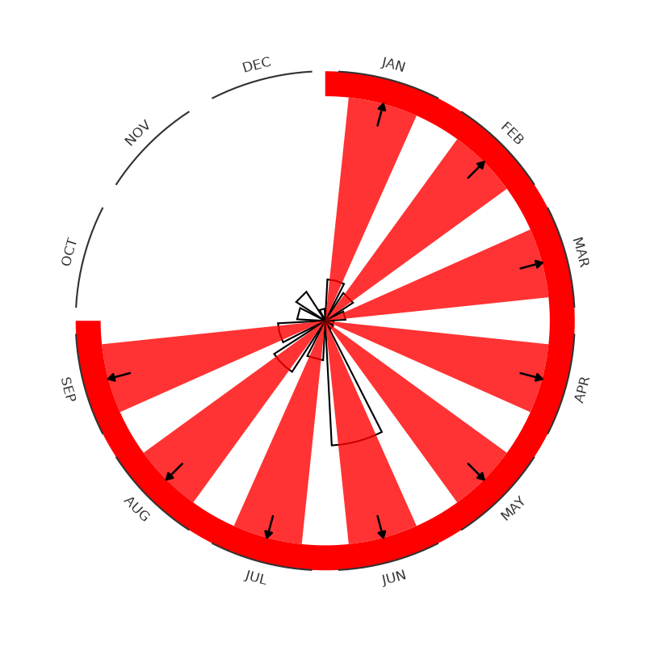

Kenya is estimated to have experienced 10,945 cases this year to date. This is 20.9× the number of cases reported in an average year. This year the dengue situation in Kenya is above average.

Updated 18 October 2026

Cuba

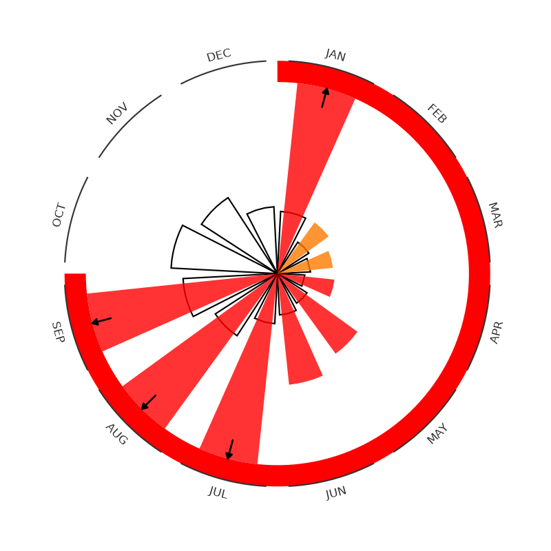

Cuba is estimated to have experienced 11,235 cases this year to date. This is 9.2× the number of cases reported in an average year. This year the dengue situation in Cuba is above average.

Updated 18 October 2026

Guyana

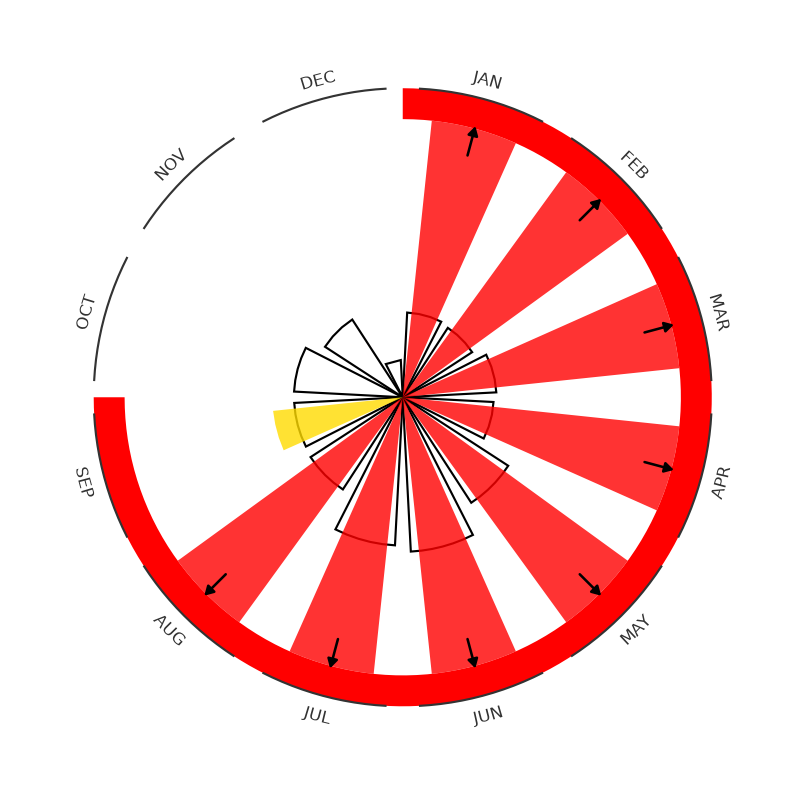

Guyana is estimated to have experienced 75,050 cases this year to date. This is 7.9× the number of cases reported in an average year. This year the dengue situation in Guyana is above average.

Updated 18 October 2026

Sudan

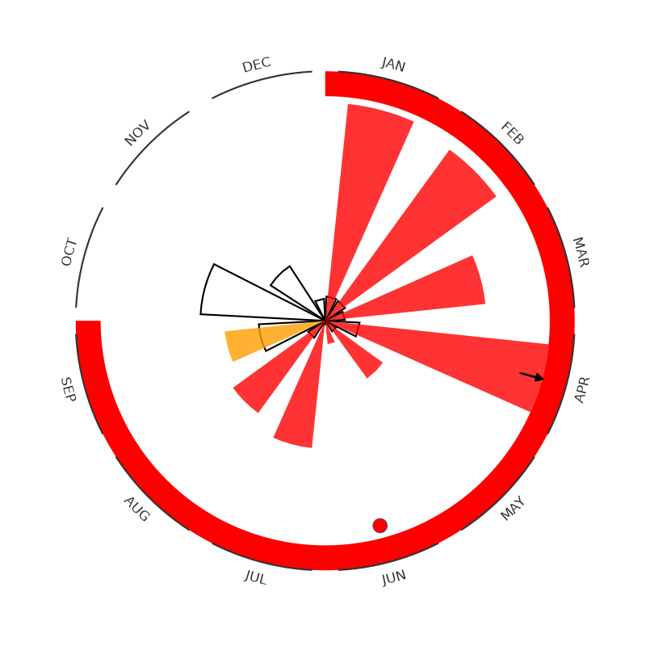

Sudan is estimated to have experienced 33,965 cases this year to date. This is 6.3× the number of cases reported in an average year. This year the dengue situation in Sudan is above average.

Updated 18 October 2026

Cambodia

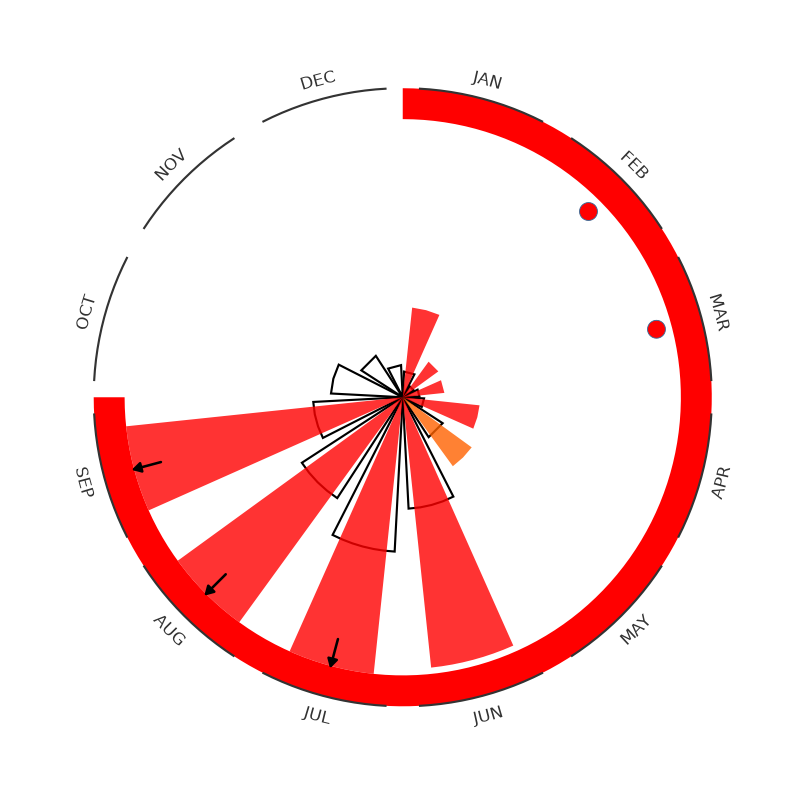

Cambodia is estimated to have experienced 113,750 cases this year to date. This is 6.2× the number of cases reported in an average year. This year the dengue situation in Cambodia is above average.

Updated 18 October 2026